# Idaho Chapter of TWS 2025 Workshop

Simona Picardi

2025-03-18

# Data manipulation, exploration, and visualization made easy: the *tidyverse* packages

Welcome to the R workshop of the Idaho Chapter of The Wildlife Society meeting 2025! In this workshop, you will learn how to use functions in the *tidyverse* packages to manipulate, wrangle, and visualize data in an automated way. We are going to start by installing and loading the necessary packages. The functions we will use to work with data come from the *tidyverse* library and the data we will be working on come from the *palmerpenguins* library.

The code below installs the packages onto your computer. This is a one-time step that won’t need to be repeated the next time you want to use these packages.

```r
install.packages("tidyverse")
install.packages("palmerpenguins")
```

Now that the packages are installed, we can load them into our R session. This will need to be repeated every time you restart R and want to use these packages.

```r
library(palmerpenguins)
library(tidyverse)
```

The data we will use today comes from an open dataset on three penguin species observed in the Palmer Archipelago, Antarctica, collected by Dr. Kristen Gorman with Palmer Station LTER. Let’s load the data into our workspace:

```r
data(package = "palmerpenguins")

(p <- penguins_raw)
```

```
## # A tibble: 344 × 17
##    studyName `Sample Number` Species         Region Island Stage `Individual ID`
##    <chr>               <dbl> <chr>           <chr>  <chr>  <chr> <chr>
##  1 PAL0708                 1 Adelie Penguin… Anvers Torge… Adul… N1A1
##  2 PAL0708                 2 Adelie Penguin… Anvers Torge… Adul… N1A2
##  3 PAL0708                 3 Adelie Penguin… Anvers Torge… Adul… N2A1
##  4 PAL0708                 4 Adelie Penguin… Anvers Torge… Adul… N2A2
##  5 PAL0708                 5 Adelie Penguin… Anvers Torge… Adul… N3A1
##  6 PAL0708                 6 Adelie Penguin… Anvers Torge… Adul… N3A2
##  7 PAL0708                 7 Adelie Penguin… Anvers Torge… Adul… N4A1
##  8 PAL0708                 8 Adelie Penguin… Anvers Torge… Adul… N4A2
##  9 PAL0708                 9 Adelie Penguin… Anvers Torge… Adul… N5A1
## 10 PAL0708                10 Adelie Penguin… Anvers Torge… Adul… N5A2
## # ℹ 334 more rows
## # ℹ 10 more variables: `Clutch Completion` <chr>, `Date Egg` <date>,
## #   `Culmen Length (mm)` <dbl>, `Culmen Depth (mm)` <dbl>,
## #   `Flipper Length (mm)` <dbl>, `Body Mass (g)` <dbl>, Sex <chr>,
## #   `Delta 15 N (o/oo)` <dbl>, `Delta 13 C (o/oo)` <dbl>, Comments <chr>
```

The data comes as a `tibble`. A `tibble` is a tabular object similar to a `data.frame`, and it is the native form in which tables are displayed in the *tidyverse*. They are interoperable, and you can easily convert one into the other, but the advantage of tibbles is that they display in a more compact way in the console without us having to take extra steps to prevent the output to flood our screen.

```r
class(p)
```

```
## [1] "tbl_df"     "tbl"        "data.frame"
```

```r
p_df <- as.data.frame(p)

head(p_df)
```

```
##   studyName Sample Number                             Species Region    Island
## 1   PAL0708             1 Adelie Penguin (Pygoscelis adeliae) Anvers Torgersen
## 2   PAL0708             2 Adelie Penguin (Pygoscelis adeliae) Anvers Torgersen
## 3   PAL0708             3 Adelie Penguin (Pygoscelis adeliae) Anvers Torgersen
## 4   PAL0708             4 Adelie Penguin (Pygoscelis adeliae) Anvers Torgersen
## 5   PAL0708             5 Adelie Penguin (Pygoscelis adeliae) Anvers Torgersen
## 6   PAL0708             6 Adelie Penguin (Pygoscelis adeliae) Anvers Torgersen
##                Stage Individual ID Clutch Completion   Date Egg
## 1 Adult, 1 Egg Stage          N1A1               Yes 2007-11-11
## 2 Adult, 1 Egg Stage          N1A2               Yes 2007-11-11
## 3 Adult, 1 Egg Stage          N2A1               Yes 2007-11-16
## 4 Adult, 1 Egg Stage          N2A2               Yes 2007-11-16
## 5 Adult, 1 Egg Stage          N3A1               Yes 2007-11-16
## 6 Adult, 1 Egg Stage          N3A2               Yes 2007-11-16
##   Culmen Length (mm) Culmen Depth (mm) Flipper Length (mm) Body Mass (g)    Sex
## 1               39.1              18.7                 181          3750   MALE
## 2               39.5              17.4                 186          3800 FEMALE
## 3               40.3              18.0                 195          3250 FEMALE
## 4                 NA                NA                  NA            NA   <NA>
## 5               36.7              19.3                 193          3450 FEMALE
## 6               39.3              20.6                 190          3650   MALE
##   Delta 15 N (o/oo) Delta 13 C (o/oo)                       Comments
## 1                NA                NA Not enough blood for isotopes.
## 2           8.94956         -24.69454                           <NA>
## 3           8.36821         -25.33302                           <NA>
## 4                NA                NA             Adult not sampled.
## 5           8.76651         -25.32426                           <NA>
## 6           8.66496         -25.29805                           <NA>
```

```r
p <- as_tibble(p_df)

head(p)
```

```
## # A tibble: 6 × 17
##   studyName `Sample Number` Species          Region Island Stage `Individual ID`
##   <chr>               <dbl> <chr>            <chr>  <chr>  <chr> <chr>
## 1 PAL0708                 1 Adelie Penguin … Anvers Torge… Adul… N1A1
## 2 PAL0708                 2 Adelie Penguin … Anvers Torge… Adul… N1A2
## 3 PAL0708                 3 Adelie Penguin … Anvers Torge… Adul… N2A1
## 4 PAL0708                 4 Adelie Penguin … Anvers Torge… Adul… N2A2
## 5 PAL0708                 5 Adelie Penguin … Anvers Torge… Adul… N3A1
## 6 PAL0708                 6 Adelie Penguin … Anvers Torge… Adul… N3A2
## # ℹ 10 more variables: `Clutch Completion` <chr>, `Date Egg` <date>,
## #   `Culmen Length (mm)` <dbl>, `Culmen Depth (mm)` <dbl>,
## #   `Flipper Length (mm)` <dbl>, `Body Mass (g)` <dbl>, Sex <chr>,
## #   `Delta 15 N (o/oo)` <dbl>, `Delta 13 C (o/oo)` <dbl>, Comments <chr>
```

## Learning *tidyverse* functions

Let’s get into the fun part and start learning how to manipulate data using the *tidyverse*.

### Selecting columns

The function `select` allows us to choose only certain columns from a `tibble`. For instance, say that we only want to select columns that contain morphometrics information about individuals:

```r
select(p,
       "Species",
       "Individual ID",
       "Culmen Length (mm)",
       "Culmen Depth (mm)",
       "Flipper Length (mm)",
       "Body Mass (g)")
```

```
## # A tibble: 344 × 6
##    Species              `Individual ID` `Culmen Length (mm)` `Culmen Depth (mm)`
##    <chr>                <chr>                          <dbl>               <dbl>
##  1 Adelie Penguin (Pyg… N1A1                            39.1                18.7
##  2 Adelie Penguin (Pyg… N1A2                            39.5                17.4
##  3 Adelie Penguin (Pyg… N2A1                            40.3                18
##  4 Adelie Penguin (Pyg… N2A2                            NA                  NA
##  5 Adelie Penguin (Pyg… N3A1                            36.7                19.3
##  6 Adelie Penguin (Pyg… N3A2                            39.3                20.6
##  7 Adelie Penguin (Pyg… N4A1                            38.9                17.8
##  8 Adelie Penguin (Pyg… N4A2                            39.2                19.6
##  9 Adelie Penguin (Pyg… N5A1                            34.1                18.1
## 10 Adelie Penguin (Pyg… N5A2                            42                  20.2
## # ℹ 334 more rows
## # ℹ 2 more variables: `Flipper Length (mm)` <dbl>, `Body Mass (g)` <dbl>
```

### Renaming columns

The column names in this dataset often contain spaces and special characters, like parentheses. This means I had to do a lot of typing in the previous piece of code, and I had to wrap column names in quotes. Tidy names contain no spaces and no special characters, and they allow us to refer to columns in *tidyverse* without having to put their names in quotes. Let’s rename the columns and give them tidy names:

```r
(p <- rename(p,
            study_name = studyName,
            sample = "Sample Number",
            species = Species,
            region = Region,
            island = Island,
            age_class = Stage,
            ind_id = "Individual ID",
            clutch_comp = "Clutch Completion",
            date_egg = "Date Egg",
            culmen_length_mm = "Culmen Length (mm)",
            culmen_depth_mm = "Culmen Depth (mm)",
            flipper_length_mm = "Flipper Length (mm)",
            body_mass_g = "Body Mass (g)",
            sex = Sex,
            delta_15_n = "Delta 15 N (o/oo)",
            delta_13_c = "Delta 13 C (o/oo)",
            comments = Comments))
```

```
## # A tibble: 344 × 17
##    study_name sample species          region island age_class ind_id clutch_comp
##    <chr>       <dbl> <chr>            <chr>  <chr>  <chr>     <chr>  <chr>
##  1 PAL0708         1 Adelie Penguin … Anvers Torge… Adult, 1… N1A1   Yes
##  2 PAL0708         2 Adelie Penguin … Anvers Torge… Adult, 1… N1A2   Yes
##  3 PAL0708         3 Adelie Penguin … Anvers Torge… Adult, 1… N2A1   Yes
##  4 PAL0708         4 Adelie Penguin … Anvers Torge… Adult, 1… N2A2   Yes
##  5 PAL0708         5 Adelie Penguin … Anvers Torge… Adult, 1… N3A1   Yes
##  6 PAL0708         6 Adelie Penguin … Anvers Torge… Adult, 1… N3A2   Yes
##  7 PAL0708         7 Adelie Penguin … Anvers Torge… Adult, 1… N4A1   No
##  8 PAL0708         8 Adelie Penguin … Anvers Torge… Adult, 1… N4A2   No
##  9 PAL0708         9 Adelie Penguin … Anvers Torge… Adult, 1… N5A1   Yes
## 10 PAL0708        10 Adelie Penguin … Anvers Torge… Adult, 1… N5A2   Yes
## # ℹ 334 more rows
## # ℹ 9 more variables: date_egg <date>, culmen_length_mm <dbl>,
## #   culmen_depth_mm <dbl>, flipper_length_mm <dbl>, body_mass_g <dbl>,
## #   sex <chr>, delta_15_n <dbl>, delta_13_c <dbl>, comments <chr>
```

### Concatenating multiple operations: the pipe

One of the best features of the tidyverse is the pipe, which looks like this: `%>%`. The pipe is an operator that allows us to concatenate multiple commands all in a row, without saving any intermediate objects. The output of the previous command becomes the input of the next. You can read the pipe as “then”. For example, in the following code, we take our penguin `data.frame`, *then* we turn it into a `tibble`, *then* we rename the columns, *then* we select the columns of interest:

```r
(morph <- p_df %>%
  as_tibble() %>%
  rename(study_name = studyName,
         sample = "Sample Number",
         species = Species,
         region = Region,
         island = Island,
         age_class = Stage,
         ind_id = "Individual ID",
         clutch_comp = "Clutch Completion",
         date_egg = "Date Egg",
         culmen_length_mm = "Culmen Length (mm)",
         culmen_depth_mm = "Culmen Depth (mm)",
         flipper_length_mm = "Flipper Length (mm)",
         body_mass_g = "Body Mass (g)",
         sex = Sex,
         delta_15_n = "Delta 15 N (o/oo)",
         delta_13_c = "Delta 13 C (o/oo)",
         comments = Comments) %>%
  select(sample,
         ind_id,
         species,
         sex,
         age_class,
         culmen_length_mm,
         culmen_depth_mm,
         flipper_length_mm,
         body_mass_g))
```

```
## # A tibble: 344 × 9
##    sample ind_id species        sex   age_class culmen_length_mm culmen_depth_mm
##     <dbl> <chr>  <chr>          <chr> <chr>                <dbl>           <dbl>
##  1      1 N1A1   Adelie Pengui… MALE  Adult, 1…             39.1            18.7
##  2      2 N1A2   Adelie Pengui… FEMA… Adult, 1…             39.5            17.4
##  3      3 N2A1   Adelie Pengui… FEMA… Adult, 1…             40.3            18
##  4      4 N2A2   Adelie Pengui… <NA>  Adult, 1…             NA              NA
##  5      5 N3A1   Adelie Pengui… FEMA… Adult, 1…             36.7            19.3
##  6      6 N3A2   Adelie Pengui… MALE  Adult, 1…             39.3            20.6
##  7      7 N4A1   Adelie Pengui… FEMA… Adult, 1…             38.9            17.8
##  8      8 N4A2   Adelie Pengui… MALE  Adult, 1…             39.2            19.6
##  9      9 N5A1   Adelie Pengui… <NA>  Adult, 1…             34.1            18.1
## 10     10 N5A2   Adelie Pengui… <NA>  Adult, 1…             42              20.2
## # ℹ 334 more rows
## # ℹ 2 more variables: flipper_length_mm <dbl>, body_mass_g <dbl>
```

### Dropping columns

The `select` function can also be used to drop columns, rather than specifying the ones we want to keep. We place a minus sign in front of the columns we want to get rid of:

```r
(morph <- morph %>%
  select(-sample))
```

```
## # A tibble: 344 × 8
##    ind_id species               sex   age_class culmen_length_mm culmen_depth_mm
##    <chr>  <chr>                 <chr> <chr>                <dbl>           <dbl>
##  1 N1A1   Adelie Penguin (Pygo… MALE  Adult, 1…             39.1            18.7
##  2 N1A2   Adelie Penguin (Pygo… FEMA… Adult, 1…             39.5            17.4
##  3 N2A1   Adelie Penguin (Pygo… FEMA… Adult, 1…             40.3            18
##  4 N2A2   Adelie Penguin (Pygo… <NA>  Adult, 1…             NA              NA
##  5 N3A1   Adelie Penguin (Pygo… FEMA… Adult, 1…             36.7            19.3
##  6 N3A2   Adelie Penguin (Pygo… MALE  Adult, 1…             39.3            20.6
##  7 N4A1   Adelie Penguin (Pygo… FEMA… Adult, 1…             38.9            17.8
##  8 N4A2   Adelie Penguin (Pygo… MALE  Adult, 1…             39.2            19.6
##  9 N5A1   Adelie Penguin (Pygo… <NA>  Adult, 1…             34.1            18.1
## 10 N5A2   Adelie Penguin (Pygo… <NA>  Adult, 1…             42              20.2
## # ℹ 334 more rows
## # ℹ 2 more variables: flipper_length_mm <dbl>, body_mass_g <dbl>
```

### Finding unique combinations

Say that we want to find all the unique combinations of individual ID, species, and sex that occur in the data. We can combine the `select` function with the `distinct` function, to return all unique combinations of the specified columns:

```r
(ind_info <- p %>%
  # Columns we want to find unique combinations of
  select(ind_id, species, sex) %>%
  distinct())
```

```
## # A tibble: 298 × 3
##    ind_id species                             sex
##    <chr>  <chr>                               <chr>
##  1 N1A1   Adelie Penguin (Pygoscelis adeliae) MALE
##  2 N1A2   Adelie Penguin (Pygoscelis adeliae) FEMALE
##  3 N2A1   Adelie Penguin (Pygoscelis adeliae) FEMALE
##  4 N2A2   Adelie Penguin (Pygoscelis adeliae) <NA>
##  5 N3A1   Adelie Penguin (Pygoscelis adeliae) FEMALE
##  6 N3A2   Adelie Penguin (Pygoscelis adeliae) MALE
##  7 N4A1   Adelie Penguin (Pygoscelis adeliae) FEMALE
##  8 N4A2   Adelie Penguin (Pygoscelis adeliae) MALE
##  9 N5A1   Adelie Penguin (Pygoscelis adeliae) <NA>
## 10 N5A2   Adelie Penguin (Pygoscelis adeliae) <NA>
## # ℹ 288 more rows
```

### Extracting single columns as vectors

Now, let’s say that we want to check how many different individual IDs exist in the data. In this case, rather than a combination of columns, we only want to find unique values in one column. The function `distinct` works on a `tibble`, while the function `unique` (which is not a *tidyverse* function, but a base R function), wants a vector as input. For this reason, using `select` before `unique` is not going to work. The function we want to use instead is `pull`. This function returns a single column as a vector. For instance, let’s see how many unique individual IDs exist in the data:

```r
p %>%
  pull(ind_id) %>%
  unique()
```

```
##   [1] "N1A1"   "N1A2"   "N2A1"   "N2A2"   "N3A1"   "N3A2"   "N4A1"   "N4A2"
##   [9] "N5A1"   "N5A2"   "N6A1"   "N6A2"   "N7A1"   "N7A2"   "N8A1"   "N8A2"
##  [17] "N9A1"   "N9A2"   "N10A1"  "N10A2"  "N11A1"  "N11A2"  "N12A1"  "N12A2"
##  [25] "N13A1"  "N13A2"  "N17A1"  "N17A2"  "N18A1"  "N18A2"  "N21A1"  "N21A2"
##  [33] "N22A1"  "N22A2"  "N23A1"  "N23A2"  "N24A1"  "N24A2"  "N25A1"  "N25A2"
##  [41] "N26A1"  "N26A2"  "N27A1"  "N27A2"  "N28A1"  "N28A2"  "N29A1"  "N29A2"
##  [49] "N30A1"  "N30A2"  "N32A1"  "N32A2"  "N34A1"  "N34A2"  "N35A1"  "N35A2"
##  [57] "N36A1"  "N36A2"  "N37A1"  "N37A2"  "N38A1"  "N38A2"  "N39A1"  "N39A2"
##  [65] "N40A1"  "N40A2"  "N41A1"  "N41A2"  "N42A1"  "N42A2"  "N44A1"  "N44A2"
##  [73] "N45A1"  "N45A2"  "N46A1"  "N46A2"  "N48A1"  "N48A2"  "N49A1"  "N49A2"
##  [81] "N50A1"  "N50A2"  "N47A1"  "N47A2"  "N51A1"  "N51A2"  "N53A1"  "N53A2"
##  [89] "N55A1"  "N55A2"  "N58A1"  "N58A2"  "N60A1"  "N60A2"  "N61A1"  "N61A2"
##  [97] "N63A1"  "N63A2"  "N64A1"  "N64A2"  "N66A1"  "N66A2"  "N67A1"  "N67A2"
## [105] "N69A1"  "N69A2"  "N71A1"  "N71A2"  "N72A1"  "N72A2"  "N73A1"  "N73A2"
## [113] "N76A1"  "N76A2"  "N77A1"  "N77A2"  "N78A1"  "N78A2"  "N79A1"  "N79A2"
## [121] "N80A1"  "N80A2"  "N81A1"  "N81A2"  "N82A1"  "N82A2"  "N83A1"  "N83A2"
## [129] "N84A1"  "N84A2"  "N85A1"  "N85A2"  "N31A1"  "N31A2"  "N33A1"  "N33A2"
## [137] "N56A1"  "N56A2"  "N14A1"  "N14A2"  "N15A1"  "N15A2"  "N16A1"  "N16A2"
## [145] "N19A1"  "N19A2"  "N20A1"  "N20A2"  "N54A1"  "N54A2"  "N43A1"  "N43A2"
## [153] "N62A1"  "N62A2"  "N68A1"  "N68A2"  "N70A1"  "N70A2"  "N89A1"  "N89A2"
## [161] "N65A1"  "N65A2"  "N74A1"  "N74A2"  "N75A1"  "N75A2"  "N86A1"  "N86A2"
## [169] "N87A1"  "N87A2"  "N88A1"  "N88A2"  "N90A1"  "N90A2"  "N92A1"  "N92A2"
## [177] "N93A1"  "N93A2"  "N94A1"  "N94A2"  "N95A1"  "N95A2"  "N96A1"  "N96A2"
## [185] "N98A1"  "N98A2"  "N99A1"  "N99A2"  "N100A1" "N100A2"
```

There are 190 unique IDs. However, the number of unique combinations of ID, species, and sex has more rows than that (298). This means there are repeated IDs in the data! What is going on?

### Filtering data

Let’s take a look, for instance, at the ID N11A1. We can use the function `filter` to subset the rows that have that ID:

```r
ind_info %>%
  filter(ind_id == "N11A1")
```

```
## # A tibble: 2 × 3
##   ind_id species                             sex
##   <chr>  <chr>                               <chr>
## 1 N11A1  Adelie Penguin (Pygoscelis adeliae) FEMALE
## 2 N11A1  Gentoo penguin (Pygoscelis papua)   FEMALE
```

It looks like this same ID was assigned to two individuals of different species. How can we find all the individual IDs that are repeated in the data?

### Grouping and doing operations by group

To find out which IDs are repeated, we can count the number of rows each individual ID appears in. We can do that by grouping rows by individual IDs and then counting the number of rows in each group:

```r
ind_info %>%
  group_by(ind_id) %>%
  tally()
```

```
## # A tibble: 190 × 2
##    ind_id     n
##    <chr>  <int>
##  1 N100A1     1
##  2 N100A2     1
##  3 N10A1      1
##  4 N10A2      1
##  5 N11A1      2
##  6 N11A2      2
##  7 N12A1      2
##  8 N12A2      2
##  9 N13A1      2
## 10 N13A2      2
## # ℹ 180 more rows
```

### Sorting results

If we want to know how many times, at most, IDs are repeated, we can sort the results of the counts by group:

```r
ind_info %>%
  group_by(ind_id) %>%
  tally() %>%
  arrange(n)
```

```
## # A tibble: 190 × 2
##    ind_id     n
##    <chr>  <int>
##  1 N100A1     1
##  2 N100A2     1
##  3 N10A1      1
##  4 N10A2      1
##  5 N14A1      1
##  6 N14A2      1
##  7 N15A1      1
##  8 N15A2      1
##  9 N16A1      1
## 10 N16A2      1
## # ℹ 180 more rows
```

That didn’t quite work… it sorted results in ascending order, so all we were able to see at a glance is that the IDs with the fewest repetitions are only used once. But what we want to do is look at the IDs with the most repetitions and find out how many times they were used. We can reverse the order:

```r
ind_info %>%
  group_by(ind_id) %>%
  tally() %>%
  arrange(desc(n))
```

```
## # A tibble: 190 × 2
##    ind_id     n
##    <chr>  <int>
##  1 N24A1      3
##  2 N24A2      3
##  3 N29A1      3
##  4 N29A2      3
##  5 N36A1      3
##  6 N38A2      3
##  7 N67A1      3
##  8 N67A2      3
##  9 N8A1       3
## 10 N8A2       3
## # ℹ 180 more rows
```

It turns out that, at most, the same ID was reused three times. Here is how to find all the IDs that were used more than once:

```r
ind_info %>%
  group_by(ind_id) %>%
  tally() %>%
  filter(n > 1)
```

```
## # A tibble: 98 × 2
##    ind_id     n
##    <chr>  <int>
##  1 N11A1      2
##  2 N11A2      2
##  3 N12A1      2
##  4 N12A2      2
##  5 N13A1      2
##  6 N13A2      2
##  7 N17A1      2
##  8 N17A2      2
##  9 N18A1      2
## 10 N18A2      2
## # ℹ 88 more rows
```

### Creating new columns

Having a column that uniquely identifies each individual is very useful, so we’re going to create a new column that contains a new individual ID, with no repetitions. For example, we can create a column with the prefix “ID” followed by an incremental number:

```r
(ind_info <- ind_info %>%
  mutate(new_id = paste0("ID", 1:nrow(.))))
```

```
## # A tibble: 298 × 4
##    ind_id species                             sex    new_id
##    <chr>  <chr>                               <chr>  <chr>
##  1 N1A1   Adelie Penguin (Pygoscelis adeliae) MALE   ID1
##  2 N1A2   Adelie Penguin (Pygoscelis adeliae) FEMALE ID2
##  3 N2A1   Adelie Penguin (Pygoscelis adeliae) FEMALE ID3
##  4 N2A2   Adelie Penguin (Pygoscelis adeliae) <NA>   ID4
##  5 N3A1   Adelie Penguin (Pygoscelis adeliae) FEMALE ID5
##  6 N3A2   Adelie Penguin (Pygoscelis adeliae) MALE   ID6
##  7 N4A1   Adelie Penguin (Pygoscelis adeliae) FEMALE ID7
##  8 N4A2   Adelie Penguin (Pygoscelis adeliae) MALE   ID8
##  9 N5A1   Adelie Penguin (Pygoscelis adeliae) <NA>   ID9
## 10 N5A2   Adelie Penguin (Pygoscelis adeliae) <NA>   ID10
## # ℹ 288 more rows
```

### Conditional value assignment

Alternatively, if we wanted something more sophisticated and we did not want to lose the original ID that was assigned to each individual, we can append to it the initial of the species and the initial of the sex. Each combination of original ID, species, and sex will now be uniquely identifiable. To do this, we use the function `mutate` that we saw above and we combine it with the function `case_when`, which performs conditional value assignment. We make a series of logical statements and specify the value that should be in the new column depending on whether those statements are true:

```r
(ind_info <- ind_info %>%
  mutate(species_initial = case_when(
    species == "Adelie Penguin (Pygoscelis adeliae)" ~ "A",
    species == "Gentoo penguin (Pygoscelis papua)" ~ "G",
    species == "Chinstrap penguin (Pygoscelis antarctica)" ~ "C"
  ),
  sex_initial = case_when(
    sex == "MALE" ~ "M",
    sex == "FEMALE" ~ "F",
    is.na(sex) ~ "U"
  )) %>%
  mutate(new_id = paste(ind_id, species_initial, sex_initial, sep = "_")) %>%
  select(-species_initial, -sex_initial))
```

```
## # A tibble: 298 × 4
##    ind_id species                             sex    new_id
##    <chr>  <chr>                               <chr>  <chr>
##  1 N1A1   Adelie Penguin (Pygoscelis adeliae) MALE   N1A1_A_M
##  2 N1A2   Adelie Penguin (Pygoscelis adeliae) FEMALE N1A2_A_F
##  3 N2A1   Adelie Penguin (Pygoscelis adeliae) FEMALE N2A1_A_F
##  4 N2A2   Adelie Penguin (Pygoscelis adeliae) <NA>   N2A2_A_U
##  5 N3A1   Adelie Penguin (Pygoscelis adeliae) FEMALE N3A1_A_F
##  6 N3A2   Adelie Penguin (Pygoscelis adeliae) MALE   N3A2_A_M
##  7 N4A1   Adelie Penguin (Pygoscelis adeliae) FEMALE N4A1_A_F
##  8 N4A2   Adelie Penguin (Pygoscelis adeliae) MALE   N4A2_A_M
##  9 N5A1   Adelie Penguin (Pygoscelis adeliae) <NA>   N5A1_A_U
## 10 N5A2   Adelie Penguin (Pygoscelis adeliae) <NA>   N5A2_A_U
## # ℹ 288 more rows
```

Let’s check that now there are as many new IDs as there are rows in the individual information table:

```r
length(unique(ind_info$new_id)) == nrow(ind_info)
```

```
## [1] TRUE
```

Great. We’re good to go!

### Joining tables

Now we want to make sure that the new ID column appears in the morphometrics table, too. We could either repeat the operation above on this table and recreate the individual ID, or we could append the new column by matching combinations of individual ID, species, and sex. Let’s do the latter:

```r
left_join(morph, ind_info)
```

```
## # A tibble: 344 × 9
##    ind_id species               sex   age_class culmen_length_mm culmen_depth_mm
##    <chr>  <chr>                 <chr> <chr>                <dbl>           <dbl>
##  1 N1A1   Adelie Penguin (Pygo… MALE  Adult, 1…             39.1            18.7
##  2 N1A2   Adelie Penguin (Pygo… FEMA… Adult, 1…             39.5            17.4
##  3 N2A1   Adelie Penguin (Pygo… FEMA… Adult, 1…             40.3            18
##  4 N2A2   Adelie Penguin (Pygo… <NA>  Adult, 1…             NA              NA
##  5 N3A1   Adelie Penguin (Pygo… FEMA… Adult, 1…             36.7            19.3
##  6 N3A2   Adelie Penguin (Pygo… MALE  Adult, 1…             39.3            20.6
##  7 N4A1   Adelie Penguin (Pygo… FEMA… Adult, 1…             38.9            17.8
##  8 N4A2   Adelie Penguin (Pygo… MALE  Adult, 1…             39.2            19.6
##  9 N5A1   Adelie Penguin (Pygo… <NA>  Adult, 1…             34.1            18.1
## 10 N5A2   Adelie Penguin (Pygo… <NA>  Adult, 1…             42              20.2
## # ℹ 334 more rows
## # ℹ 3 more variables: flipper_length_mm <dbl>, body_mass_g <dbl>, new_id <chr>
```

If we don’t specify which columns we want to join by, `left_join` will automatically choose all the columns that share the same name in both tables. We could decide instead to join based on a subset of those, for example, the individual ID. What happens if we do that?

```r
left_join(morph, ind_info, by = "ind_id")
```

```
## # A tibble: 610 × 11
##    ind_id species.x             sex.x age_class culmen_length_mm culmen_depth_mm
##    <chr>  <chr>                 <chr> <chr>                <dbl>           <dbl>
##  1 N1A1   Adelie Penguin (Pygo… MALE  Adult, 1…             39.1            18.7
##  2 N1A1   Adelie Penguin (Pygo… MALE  Adult, 1…             39.1            18.7
##  3 N1A2   Adelie Penguin (Pygo… FEMA… Adult, 1…             39.5            17.4
##  4 N1A2   Adelie Penguin (Pygo… FEMA… Adult, 1…             39.5            17.4
##  5 N2A1   Adelie Penguin (Pygo… FEMA… Adult, 1…             40.3            18
##  6 N2A1   Adelie Penguin (Pygo… FEMA… Adult, 1…             40.3            18
##  7 N2A2   Adelie Penguin (Pygo… <NA>  Adult, 1…             NA              NA
##  8 N2A2   Adelie Penguin (Pygo… <NA>  Adult, 1…             NA              NA
##  9 N3A1   Adelie Penguin (Pygo… FEMA… Adult, 1…             36.7            19.3
## 10 N3A2   Adelie Penguin (Pygo… MALE  Adult, 1…             39.3            20.6
## # ℹ 600 more rows
## # ℹ 5 more variables: flipper_length_mm <dbl>, body_mass_g <dbl>,
## #   species.y <chr>, sex.y <chr>, new_id <chr>
```

This is not quite what we wanted. We ended up with way too many rows, because some individual IDs appear in combination with different species, sexes, or new IDs. So, the first output we got was actually correct. But this goes to show how important it is to be explicit about which columns we want to join tables by. Let’s explicitly say that we want to join the tables based on combinations of individual ID, species, and sex:

```r
(morph <- left_join(morph, ind_info, by = c("ind_id", "species", "sex")))
```

```
## # A tibble: 344 × 9
##    ind_id species               sex   age_class culmen_length_mm culmen_depth_mm
##    <chr>  <chr>                 <chr> <chr>                <dbl>           <dbl>
##  1 N1A1   Adelie Penguin (Pygo… MALE  Adult, 1…             39.1            18.7
##  2 N1A2   Adelie Penguin (Pygo… FEMA… Adult, 1…             39.5            17.4
##  3 N2A1   Adelie Penguin (Pygo… FEMA… Adult, 1…             40.3            18
##  4 N2A2   Adelie Penguin (Pygo… <NA>  Adult, 1…             NA              NA
##  5 N3A1   Adelie Penguin (Pygo… FEMA… Adult, 1…             36.7            19.3
##  6 N3A2   Adelie Penguin (Pygo… MALE  Adult, 1…             39.3            20.6
##  7 N4A1   Adelie Penguin (Pygo… FEMA… Adult, 1…             38.9            17.8
##  8 N4A2   Adelie Penguin (Pygo… MALE  Adult, 1…             39.2            19.6
##  9 N5A1   Adelie Penguin (Pygo… <NA>  Adult, 1…             34.1            18.1
## 10 N5A2   Adelie Penguin (Pygo… <NA>  Adult, 1…             42              20.2
## # ℹ 334 more rows
## # ℹ 3 more variables: flipper_length_mm <dbl>, body_mass_g <dbl>, new_id <chr>
```

### Relocating columns

It’s useful to have the individual ID be on the left hand side of the table. Let’s move the column we just created. Based on personal preference, we could place it, for instance, after the original individual ID or before it:

```r
morph %>%
  relocate(new_id, .after = ind_id)
```

```
## # A tibble: 344 × 9
##    ind_id new_id   species      sex   age_class culmen_length_mm culmen_depth_mm
##    <chr>  <chr>    <chr>        <chr> <chr>                <dbl>           <dbl>
##  1 N1A1   N1A1_A_M Adelie Peng… MALE  Adult, 1…             39.1            18.7
##  2 N1A2   N1A2_A_F Adelie Peng… FEMA… Adult, 1…             39.5            17.4
##  3 N2A1   N2A1_A_F Adelie Peng… FEMA… Adult, 1…             40.3            18
##  4 N2A2   N2A2_A_U Adelie Peng… <NA>  Adult, 1…             NA              NA
##  5 N3A1   N3A1_A_F Adelie Peng… FEMA… Adult, 1…             36.7            19.3
##  6 N3A2   N3A2_A_M Adelie Peng… MALE  Adult, 1…             39.3            20.6
##  7 N4A1   N4A1_A_F Adelie Peng… FEMA… Adult, 1…             38.9            17.8
##  8 N4A2   N4A2_A_M Adelie Peng… MALE  Adult, 1…             39.2            19.6
##  9 N5A1   N5A1_A_U Adelie Peng… <NA>  Adult, 1…             34.1            18.1
## 10 N5A2   N5A2_A_U Adelie Peng… <NA>  Adult, 1…             42              20.2
## # ℹ 334 more rows
## # ℹ 2 more variables: flipper_length_mm <dbl>, body_mass_g <dbl>
```

```r
morph <- morph %>%
  relocate(new_id, .before = ind_id)
```

### Limiting results and subsetting rows by position

It is useful to be able to look at just a subset of the rows. For example, we might just want to see the first row of a dataset; we might just want to see the first three; we might want to see a specific subset of non-consecutive rows; or we might want to see the first row for each group (e.g., for each species, or for each combination of species and sex). The `slice` funciton can do all of those things:

```r
morph %>%
  slice(1)
```

```
## # A tibble: 1 × 9
##   new_id   ind_id species       sex   age_class culmen_length_mm culmen_depth_mm
##   <chr>    <chr>  <chr>         <chr> <chr>                <dbl>           <dbl>
## 1 N1A1_A_M N1A1   Adelie Pengu… MALE  Adult, 1…             39.1            18.7
## # ℹ 2 more variables: flipper_length_mm <dbl>, body_mass_g <dbl>
```

```r
morph %>%
  slice(1:3)
```

```
## # A tibble: 3 × 9
##   new_id   ind_id species       sex   age_class culmen_length_mm culmen_depth_mm
##   <chr>    <chr>  <chr>         <chr> <chr>                <dbl>           <dbl>
## 1 N1A1_A_M N1A1   Adelie Pengu… MALE  Adult, 1…             39.1            18.7
## 2 N1A2_A_F N1A2   Adelie Pengu… FEMA… Adult, 1…             39.5            17.4
## 3 N2A1_A_F N2A1   Adelie Pengu… FEMA… Adult, 1…             40.3            18
## # ℹ 2 more variables: flipper_length_mm <dbl>, body_mass_g <dbl>
```

```r
morph %>%
  slice(c(1, 3, 10, 25))
```

```
## # A tibble: 4 × 9
##   new_id    ind_id species      sex   age_class culmen_length_mm culmen_depth_mm
##   <chr>     <chr>  <chr>        <chr> <chr>                <dbl>           <dbl>
## 1 N1A1_A_M  N1A1   Adelie Peng… MALE  Adult, 1…             39.1            18.7
## 2 N2A1_A_F  N2A1   Adelie Peng… FEMA… Adult, 1…             40.3            18
## 3 N5A2_A_U  N5A2   Adelie Peng… <NA>  Adult, 1…             42              20.2
## 4 N13A1_A_M N13A1  Adelie Peng… MALE  Adult, 1…             38.8            17.2
## # ℹ 2 more variables: flipper_length_mm <dbl>, body_mass_g <dbl>
```

```r
morph %>%
  group_by(species) %>%
  slice(1)
```

```
## # A tibble: 3 × 9
## # Groups:   species [3]
##   new_id    ind_id species      sex   age_class culmen_length_mm culmen_depth_mm
##   <chr>     <chr>  <chr>        <chr> <chr>                <dbl>           <dbl>
## 1 N1A1_A_M  N1A1   Adelie Peng… MALE  Adult, 1…             39.1            18.7
## 2 N61A1_C_F N61A1  Chinstrap p… FEMA… Adult, 1…             46.5            17.9
## 3 N31A1_G_F N31A1  Gentoo peng… FEMA… Adult, 1…             46.1            13.2
## # ℹ 2 more variables: flipper_length_mm <dbl>, body_mass_g <dbl>
```

```r
morph %>%
  group_by(species, sex) %>%
  slice(1)
```

```
## # A tibble: 8 × 9
## # Groups:   species, sex [8]
##   new_id    ind_id species      sex   age_class culmen_length_mm culmen_depth_mm
##   <chr>     <chr>  <chr>        <chr> <chr>                <dbl>           <dbl>
## 1 N1A2_A_F  N1A2   Adelie Peng… FEMA… Adult, 1…             39.5            17.4
## 2 N1A1_A_M  N1A1   Adelie Peng… MALE  Adult, 1…             39.1            18.7
## 3 N2A2_A_U  N2A2   Adelie Peng… <NA>  Adult, 1…             NA              NA
## 4 N61A1_C_F N61A1  Chinstrap p… FEMA… Adult, 1…             46.5            17.9
## 5 N61A2_C_M N61A2  Chinstrap p… MALE  Adult, 1…             50              19.5
## 6 N31A1_G_F N31A1  Gentoo peng… FEMA… Adult, 1…             46.1            13.2
## 7 N31A2_G_M N31A2  Gentoo peng… MALE  Adult, 1…             50              16.3
## 8 N46A1_G_U N46A1  Gentoo peng… <NA>  Adult, 1…             44.5            14.3
## # ℹ 2 more variables: flipper_length_mm <dbl>, body_mass_g <dbl>
```

### Putting it all together

With just a handful of *tidyverse* functions, we have now built a pretty powerful toolbox that allows us to manipulate data to change its format or to answer questions about it. Let’s practice with a few tasks.

#### Task 1

Count how many individuals, within each combination of species and sex, weigh more than 4 kilograms.

```r
(over4kg <- morph %>%
  mutate(body_mass_kg = body_mass_g/1000) %>%
  filter(body_mass_kg > 4) %>%
  group_by(species, sex) %>%
  tally())
```

```
## # A tibble: 7 × 3
## # Groups:   species [3]
##   species                                   sex        n
##   <chr>                                     <chr>  <int>
## 1 Adelie Penguin (Pygoscelis adeliae)       MALE      34
## 2 Adelie Penguin (Pygoscelis adeliae)       <NA>       1
## 3 Chinstrap penguin (Pygoscelis antarctica) FEMALE     1
## 4 Chinstrap penguin (Pygoscelis antarctica) MALE      14
## 5 Gentoo penguin (Pygoscelis papua)         FEMALE    57
## 6 Gentoo penguin (Pygoscelis papua)         MALE      61
## 7 Gentoo penguin (Pygoscelis papua)         <NA>       4
```

#### Task 2

Formulate the previous values as proportions of the total number of individuals for each combination of species and sex.

```r
(n_by_species_sex <- morph %>%
  group_by(species, sex) %>%
  tally())
```

```
## # A tibble: 8 × 3
## # Groups:   species [3]
##   species                                   sex        n
##   <chr>                                     <chr>  <int>
## 1 Adelie Penguin (Pygoscelis adeliae)       FEMALE    73
## 2 Adelie Penguin (Pygoscelis adeliae)       MALE      73
## 3 Adelie Penguin (Pygoscelis adeliae)       <NA>       6
## 4 Chinstrap penguin (Pygoscelis antarctica) FEMALE    34
## 5 Chinstrap penguin (Pygoscelis antarctica) MALE      34
## 6 Gentoo penguin (Pygoscelis papua)         FEMALE    58
## 7 Gentoo penguin (Pygoscelis papua)         MALE      61
## 8 Gentoo penguin (Pygoscelis papua)         <NA>       5
```

```r
(over4kg %>%
  left_join(n_by_species_sex, by = c("species", "sex")) %>%
  rename(n_4kg = n.x, n = n.y) %>%
  mutate(prop_4kg = n_4kg/n))
```

```
## # A tibble: 7 × 5
## # Groups:   species [3]
##   species                                   sex    n_4kg     n prop_4kg
##   <chr>                                     <chr>  <int> <int>    <dbl>
## 1 Adelie Penguin (Pygoscelis adeliae)       MALE      34    73   0.466
## 2 Adelie Penguin (Pygoscelis adeliae)       <NA>       1     6   0.167
## 3 Chinstrap penguin (Pygoscelis antarctica) FEMALE     1    34   0.0294
## 4 Chinstrap penguin (Pygoscelis antarctica) MALE      14    34   0.412
## 5 Gentoo penguin (Pygoscelis papua)         FEMALE    57    58   0.983
## 6 Gentoo penguin (Pygoscelis papua)         MALE      61    61   1
## 7 Gentoo penguin (Pygoscelis papua)         <NA>       4     5   0.8
```

#### Task 3

It looks like Gentoo penguins are generally much bigger than Adelie and Chinstrap. How to they compare in terms of flipper length? Calculate the minimum, mean, and maximum flipper length for each species.

```r
morph %>%
  group_by(species) %>%
  summarize(min = min(flipper_length_mm),
            mean = mean(flipper_length_mm),
            max = max(flipper_length_mm))
```

```
## # A tibble: 3 × 4
##   species                                     min  mean   max
##   <chr>                                     <dbl> <dbl> <dbl>
## 1 Adelie Penguin (Pygoscelis adeliae)          NA   NA     NA
## 2 Chinstrap penguin (Pygoscelis antarctica)   178  196.   212
## 3 Gentoo penguin (Pygoscelis papua)            NA   NA     NA
```

```r
morph %>%
  group_by(species) %>%
  summarize(min = min(flipper_length_mm, na.rm = TRUE),
            mean = mean(flipper_length_mm, na.rm = TRUE),
            max = max(flipper_length_mm, na.rm = TRUE))
```

```
## # A tibble: 3 × 4
##   species                                     min  mean   max
##   <chr>                                     <dbl> <dbl> <dbl>
## 1 Adelie Penguin (Pygoscelis adeliae)         172  190.   210
## 2 Chinstrap penguin (Pygoscelis antarctica)   178  196.   212
## 3 Gentoo penguin (Pygoscelis papua)           203  217.   231
```

## Data visualization with ggplot2

The `ggplot2` package allows us to produce beautiful data visualizations, even quite complex ones in an automated and simple way.

The logic of `ggplot` follows the “Grammar of Graphics” framework, which was first introduced in a book by Leland Wilkinson. This framework concisely describes the different components of a graphic. At a minimum, a plot is composed of data, aesthetics, and geometries:

- Data: this is the data that are represented on a plot;
- Aesthetics: these are the variables that are represented on the plot (e.g., what goes on the axes, or what is encoded with different symbols and colors);
- Geometries: these are the actual symbols that appear on the plot (points, lines, etc.)

On top of these fundamental components, there can be additional elements for customization. The plot is initialized using the `ggplot` function, and all elements get added as layers connected by `+` signs.

### Boxplot of body mass by species

Let’s make a boxplot of penguin body mass by species. Here, our data is the penguin dataset. Our aesthetics include the variable on the x axis (the species), the variable on the y axis (the body mass), and the color of our boxplots (which will be in different colors depending on the species). The geometries on the plot will be the boxplots and the original data points (jittered a little bit so that they are not all on top of each other). Since the species names are already on the x axis, the legend is redundant and we can remove it. We complete the plot with a clean theme, nice axis labels, and a nice color palette.

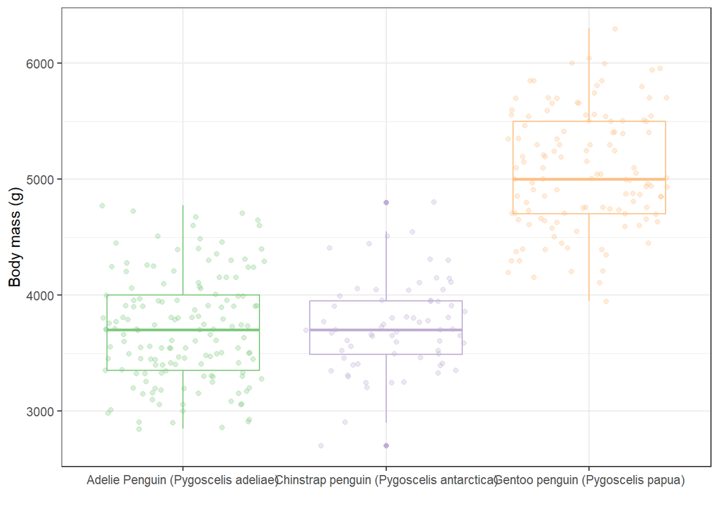

```r
ggplot(p, aes(y = body_mass_g, x = species, color = species)) +
  geom_boxplot() +
  geom_jitter(alpha = 0.3) +
  theme_bw() +
  labs(x = "", y = "Body mass (g)", color = "Species") +
  theme(legend.position = "none") +
  scale_color_brewer(palette = "Accent")
```

### Density plot of flipper length by species

Let’s make a density plot of penguin flipper length by species. Again, our data is the penguin dataset. The aesthetics include the variable on the x axis (the flipper length) and the variable that we will use to assign a fill color to each density curve (the species). Because this is a density plot, the variable on the y axis will be the density, which is calculated automatically by `geom_density` and we do not need to specify that in the aesthetics. We then add our geometry (the density curves). We complete the plot with a clean theme, nice axis labels, and a nice color palette, and we customize the position of the legend on the plot.

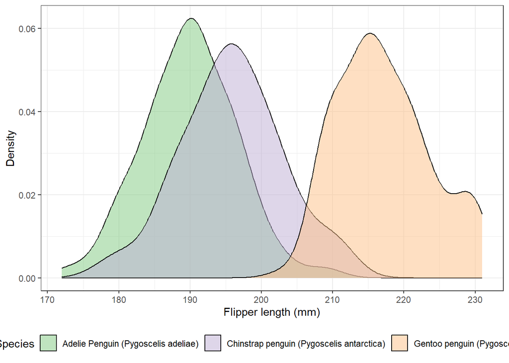

```r
ggplot(p, aes(x = flipper_length_mm, fill = species)) +
  geom_density(alpha = 0.5) +
  theme_bw() +
  labs(x = "Flipper length (mm)", y = "Density", fill = "Species") +
  theme(legend.position = "bottom") +
  scale_fill_brewer(palette = "Accent")
```

### Scatterplot of isotopic values by species and island

Let’s make a scatterplot of isotopic values (carbon and nitrogen) for penguins by species and island. Here, the aesthetics will be the two isotope variables on the x and y axes, and the species as the color variable. Our geometries will be points, and we will have a different panel for each island. We complete the plot with a clean theme, nice axis labels, and a color palette.

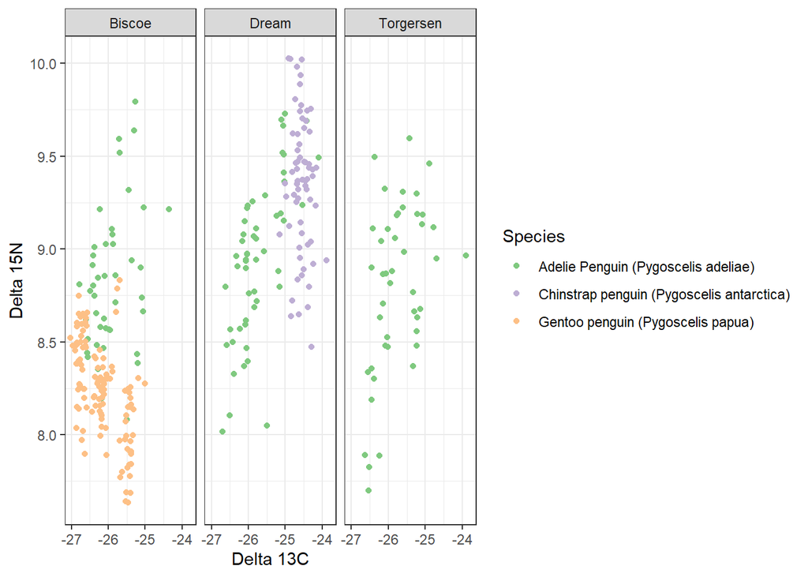

```r
ggplot(p, aes(x = delta_13_c, y = delta_15_n, color = species)) +
  geom_point() +
  facet_wrap(~ island) +
  labs(x = "Delta 13C", y = "Delta 15N", color = "Species") +
  theme_bw() +
  scale_color_brewer(palette = "Accent")
```

### Scatterplot of culmen depth and length by body mass and species

Presumably, larger penguins will simultaneously have longer limbs and higher body mass. Let’s see if this holds true by making a scatterplot of culmen depth and length by body mass and species. Here, our x and y aesthetics will be the culmen length and depth, respectively. The color aesthetic will be the species. We can add an additional aesthetic by making the size of the points vary with the value of body mass. We complete the plot with a clean theme, nice axis labels, and a nice color palette. Notice that in this case, I changed the order in which I specified the customization options, because it does not matter which order they get added in.

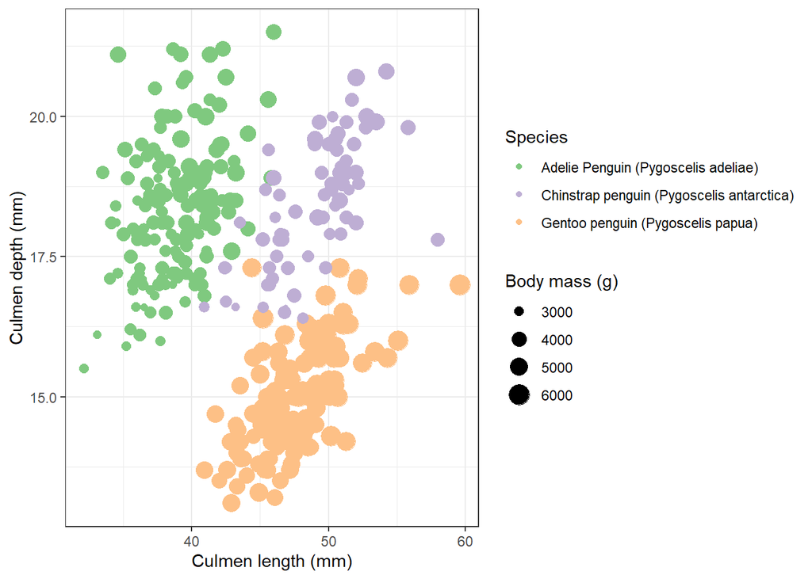

```r
ggplot(p, aes(x = culmen_length_mm, y = culmen_depth_mm,
              color = species, size = body_mass_g)) +
  geom_point() +
  scale_color_brewer(palette = "Accent") +
  labs(x = "Culmen length (mm)", y = "Culmen depth (mm)",
       color = "Species", size = "Body mass (g)") +
  theme_bw()
```

### Adding regression lines with confidence intervals

A common scenario is wanting to create a plot of our data overlaid to the output of a model, for instance, a linear regression. To do that, we have to take a few extra steps before we can create the plot. First, we need to run a regression model and generate predictions from it.

```r
mod <- lm(culmen_depth_mm ~ culmen_length_mm * species, data = p)

new_data <- expand.grid(species = factor(unique(p$species)),
            culmen_length_mm = seq(min(p$culmen_length_mm, na.rm = TRUE),
                                   max(p$culmen_length_mm, na.rm = TRUE),
                                   length.out = 100))

preds <- predict(mod, newdata = new_data, se.fit = TRUE)

res <- new_data %>%
  mutate(culmen_depth_mm = preds$fit,
         culmen_depth_lwr_ci = preds$fit - preds$se.fit * 1.96,
         culmen_depth_upr_ci = preds$fit + preds$se.fit * 1.96)
```

Now we are ready to plot. We can take the code from the previous plot and include a ribbon for the confidence intervals and a line for the mean prediction in addition to the points for the raw data. Because we want the size aesthetic to only apply to the points, we will move it from the general `ggplot` function into the appropriate layer. Note that, in this plot, we are combining two datasets: the raw penguin data (for the points) and the predictions table (for the line and ribbon). We can specify different datasets in different layers. The names of the x and y variables, as well as the name of the color variable, are the same in both data frames, so we can define those aesthetics in the main `ggplot` layer. For the ribbon layer, we will need to add three more aesthetics: the minimum y value at which the ribbon should start, the maximum y value at which it should end, and the color we want the inside of the ribbon to be. We can add some transparency to make sure we can still see the line on top of it. In this case, we have both a color and a fill variable for different components of the plot, so we want to specify the same palette for both. Notice that, in this case, it was important to add the layers in the right order because we needed the line to be on top of the ribbon, which in turn is on top of the points, for everything to be visible. We complete the plot with a clean theme and nice axis labels.

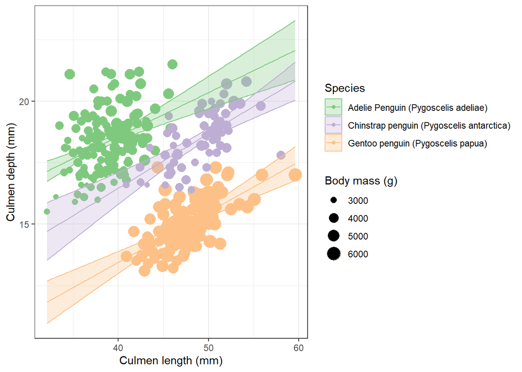

```r
ggplot(p, aes(x = culmen_length_mm, y = culmen_depth_mm, color = species)) +
  geom_point(aes(size = body_mass_g)) +
  geom_ribbon(data = res,
              mapping = aes(ymin = culmen_depth_lwr_ci,
                            ymax = culmen_depth_upr_ci,
                            fill = species),
              alpha = 0.3) +
  geom_line(data = res) +
  scale_color_brewer(palette = "Accent") +
  scale_fill_brewer(palette = "Accent") +
  labs(x = "Culmen length (mm)", y = "Culmen depth (mm)",
       color = "Species", fill = "Species", size = "Body mass (g)") +
  theme_bw()
```

### Scatterplot of flipper and culmen length by body mass and sex (Adelie only)

We can seamlessly combine the *tidyverse* syntax we learned in the first part of the workshop with `ggplot2` functions. Let’s make an example of that by creating a scatterplot of flipper and culmen length by body mass and sex for Adelie penguins only. Instead of filtering Adelie penguins and creating a separate object for that subset of data, we can directly pipe our filtered dataset into the `ggplot` function, and it will be used as the input data. We will also get rid of individuals for which the sex was not recorded. Then, we specify our aesthetics: culmen and flipper length go on the x and y axes, respectively, and the points will be colored depending on the value of body mass. Notice that this is the first time we use a continuous color palette. We separate sexes into two different panels. We increase the size of the points. We complete the plot with a clean theme and nice axis labels.

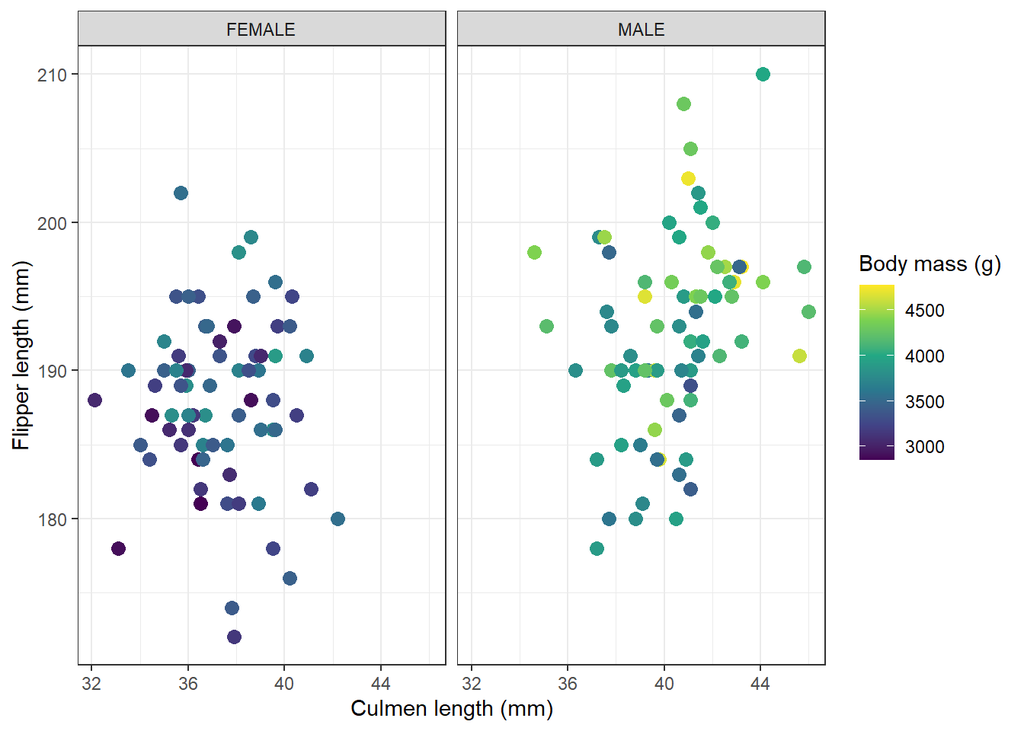

```r
p %>%
  filter(grepl("Adelie", species) &
           !is.na(sex)) %>%
  ggplot(aes(x = culmen_length_mm, y = flipper_length_mm,
              color = body_mass_g)) +
  geom_point(size = 3) +
  facet_wrap(~ sex) +
  scale_color_viridis_c() +
  labs(x = "Culmen length (mm)", y = "Flipper length (mm)",
       color = "Body mass (g)") +
  theme_bw()
```